# Reproducible Research: Peer Assessment 1

first let’s load the libraries we will use.

```r
library(Hmisc) # used for imputation, should be loaded before 'psych'!
```

```r
library(ggplot2) # prettier plots
library(psych) # describe function
library(knitr) # tables, mainly
```

## 0.1 Loading and preprocessing the data

Let’s load the data. We start by

1. unzipping it,
2. reading it and
3. having a quick look…

```r
unzip('activity.zip')
data <- read.csv2("activity.csv", sep=",")
kable(head(data) ,
      digits = 2 ,
      caption = "A quick preview of the dataset" ,
      align="c"
      )
```

A quick preview of the dataset

| steps | date | interval |
| --- | --- | --- |
| NA | 2012-10-01 | 0 |
| NA | 2012-10-01 | 5 |
| NA | 2012-10-01 | 10 |
| NA | 2012-10-01 | 15 |
| NA | 2012-10-01 | 20 |
| NA | 2012-10-01 | 25 |

```r
kable(summary(data) ,
      digits = 2 ,
      caption = "Some statistics about our dataset")
```

Some statistics about our dataset

|  | steps | date | interval |
| --- | --- | --- | --- |
|  | Min. : 0.00 | 2012-10-01: 288 | Min. : 0.0 |
|  | 1st Qu.: 0.00 | 2012-10-02: 288 | 1st Qu.: 588.8 |
|  | Median : 0.00 | 2012-10-03: 288 | Median :1177.5 |
|  | Mean : 37.38 | 2012-10-04: 288 | Mean :1177.5 |
|  | 3rd Qu.: 12.00 | 2012-10-05: 288 | 3rd Qu.:1766.2 |
|  | Max. :806.00 | 2012-10-06: 288 | Max. :2355.0 |
|  | NA’s :2304 | (Other) :15840 | NA |

## 0.2 What is mean total number of steps taken per day?

Now we focus on the steps taken each day. We do so by aggregating the steps by each unique day, using the `aggregate` function.

```
## stat_bin: binwidth defaulted to range/30. Use 'binwidth = x' to adjust this.
```

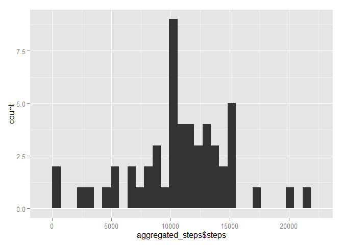

```r
aggregated_steps <- aggregate(data$steps ,
                              by = list(data$date) ,
                              FUN = sum)
names(aggregated_steps) <- c('date','steps') # Let's keep the naming of columns the same!
qplot(aggregated_steps$steps)
```

The `mean` is:

```r
mean(aggregated_steps$steps, na.rm = T)
```

```
## [1] 10766.19
```

The `median`:

```r
median(aggregated_steps$steps, na.rm = T)
```

```
## [1] 10765
```

Or to be thorough:

```r
kable(describe(aggregated_steps$steps) ,
      digits = 2 ,
      align = 'c' ,
      row.names = F ,
      caption = "Statistics about aggregated steps")
```

Statistics about aggregated steps

| vars | n | mean | sd | median | trimmed | mad | min | max | range | skew | kurtosis | se |
| --- | --- | --- | --- | --- | --- | --- | --- | --- | --- | --- | --- | --- |
| 1 | 53 | 10766.19 | 4269.18 | 10765 | 10940.02 | 3140.15 | 41 | 21194 | 21153 | -0.3 | 0.59 | 80.55 |

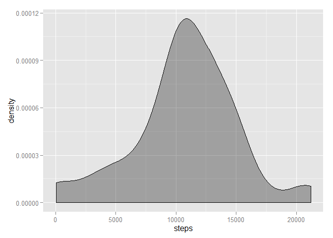

```r
ggplot(aggregated_steps, aes(x=steps))+geom_density(fill=1, alpha=.3)
```

## 0.3 What is the average daily activity pattern?

So what does the day look like for our fitbit/jawbone wearing subject? for that, we turn to another `aggregation`!

What we will also do is divide the intervals by *100*, giving us the hours!

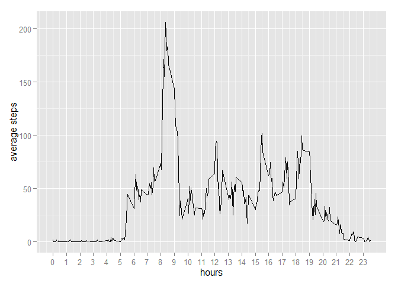

```r
interval_agg <- aggregate(data$steps ,
                          by = list(data$interval) ,
                          FUN = mean ,
                          na.rm = T )

names(interval_agg)<-c('interval','steps')

interval_agg$interval <- interval_agg$interval / 100

ggplot(interval_agg, aes(interval,steps))+geom_line()+xlab("hours")+ylab("average steps")+scale_x_continuous(breaks=seq(0,23.55,1))
```

As you may have expected from our plot, our subject is mostly active between 8 and 9. The most active time in terms of steps (on average) is:

```r
interval_agg$interval[interval_agg$steps==max(interval_agg$steps)] # that is: 08:35
```

```
## [1] 8.35
```

## 0.4 Imputing missing values

Unfortunately, there are missing values in our dataset.

```r
paste(c("There are",length(data$steps[is.na(data$steps)==T]), "missing."  ), collapse=" ")
```

```
## [1] "There are 2304 missing."
```

```r
paste(c("Which amounts to",length(data$steps[is.na(data$steps)==T])/length(data$steps)*100,'%'), collapse = " ")
```

```
## [1] "Which amounts to 13.1147540983607 %"
```

We will want to impute some missing values. There are several ways to do this, ranging from [advanced](http://www.jstatsoft.org/v45/i02/paper) to [simple](http://www.r-bloggers.com/example-2014-5-simple-mean-imputation/), but we will be [**generic**](http://svitsrv25.epfl.ch/R-doc/library/Hmisc/html/impute.html). Just think of it as an assumption that the [regression towards the mean](http://en.wikipedia.org/wiki/Regression_toward_the_mean) holds.

```r
aggregated_steps$steps.i <- impute(aggregated_steps$steps, mean, na.rm=T)
```

So how does that change our estimates?

The `mean` is:

```r
mean(aggregated_steps$steps.i, na.rm = T)
```

```
## [1] 10766.19
```

The `median`:

```r
median(aggregated_steps$steps.i, na.rm = T)
```

```
## [1] 10766.19*
```

Or to be thorough:

```r
kable(describe(aggregated_steps$steps.i) ,
      digits = 2 ,
      align = 'c' ,
      row.names = F ,
      caption = "Statistics about aggregated steps")
```

Statistics about aggregated steps

| vars | n | mean | sd | median | trimmed | mad | min | max | range | skew | kurtosis | se |
| --- | --- | --- | --- | --- | --- | --- | --- | --- | --- | --- | --- | --- |
| 1 | 61 | 10766.19 | 3974.39 | 10766.19 | 10947.4 | 2854.28 | 41 | 21194 | 21153 | -0.32 | 1.15 | 65.15 |

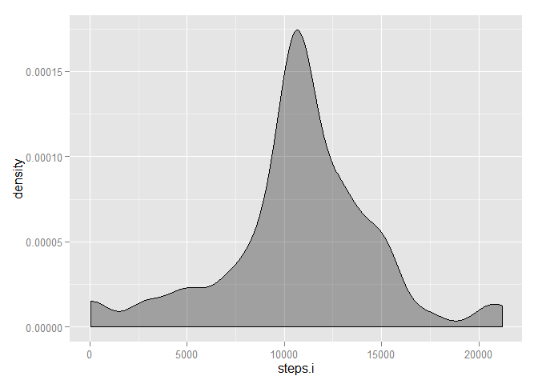

```r
ggplot(aggregated_steps, aes(x=steps.i))+geom_density(fill=1, alpha=.3)
```

## 0.5 Are there differences in activity patterns between weekdays and weekends?

First, let’s look at the getting the weekdays.

```r
data$weekdays <- weekdays(as.Date(data$date)) # sorry if it's Dutch on you machine...
```

So, now we aggregate and ecludiate!

```r
weekday_agg_mean <- aggregate(data$steps , by = list(data$weekdays), FUN = mean, na.rm=T)
weekday_agg_sd <- aggregate(data$steps , by = list(data$weekdays) , FUN = sd, na.rm=T)
both_weekday <- merge(weekday_agg_mean, weekday_agg_sd, by = "Group.1")

names(both_weekday)<-c("weekday","mean","st.dev")
both_weekday$weekday<-factor(both_weekday$weekday, levels = c("maandag", "dinsdag","woensdag","donderdag","vrijdag","zaterdag","zondag"))
summary(both_weekday)
```

```
##       weekday       mean           st.dev
##  maandag  :1   Min.   :28.52   Min.   : 99.22
##  dinsdag  :1   1st Qu.:32.85   1st Qu.:104.31
##  woensdag :1   Median :40.94   Median :114.85
##  donderdag:1   Mean   :37.75   Mean   :112.06
##  vrijdag  :1   3rd Qu.:42.77   3rd Qu.:120.08
##  zaterdag :1   Max.   :43.53   Max.   :121.61
##  zondag   :1
```

We can now look at the mean number of steps each day

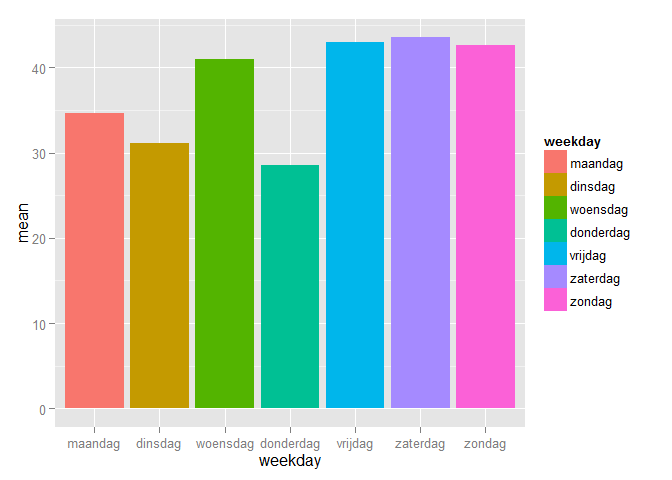

```r
ggplot(both_weekday, aes(x = weekday, y = mean, fill=weekday))+geom_bar(stat="identity")
```

And the standard deviation (which tells us something about the stress levels of our subject).

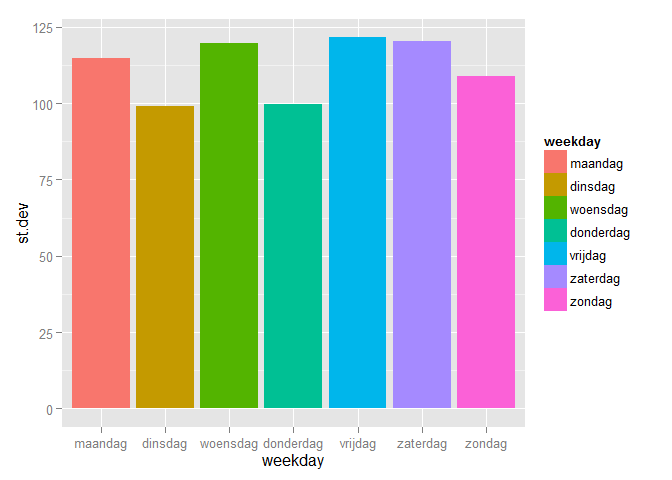

```r
ggplot(both_weekday, aes(x=weekday, fill=weekday, y=st.dev))+geom_bar(stat="identity")
```

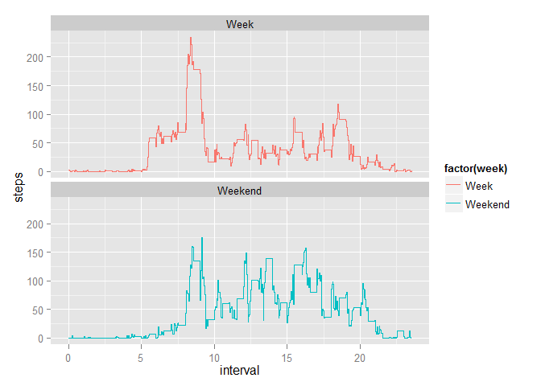

```r
# split the data by the working-week and weekend
week <- data[data$weekday %in% c("maandag","dinsdag","woensdag","donderdag","vrijdag"),]
weekend <- data[!data$weekday %in% c("maandag","dinsdag","woensdag","donderdag","vrijdag"),]
# Aggregate each dataset by interval
weekint <- aggregate(week$steps, by = list(week$interval), FUN = mean, na.rm = T)
weekendint <- aggregate(weekend$steps, by = list(weekend$interval), FUN = mean, na.rm = T)
# Add distinguishing feature
weekint$week<- "Week"
weekendint$week<- "Weekend"
all <- rbind(weekint,weekendint)
names(all)<-c("interval","steps","week")
all$interval <- all$interval / 100
# Plot the results
ggplot(all,aes(interval,steps,color=factor(week)))+geom_step()+facet_wrap(~week,nrow=2)
```